# Equation de Boltzmann

## Milieu infini homogène critique

Considérons le système suivant:

- milieu infini
- Une seule énergie
- Diffusion et fission isotropes
- Notons $\nu$ le nombre moyen de neutron par fission
- $\Sigma_t$, $\Sigma_s$, $\Sigma_f$ sont respectivement les sections macroscopiques totale, de diffusion (scattering) et de fission
1. Ecrire l'equation du transport critique
2. Trouver le $k_{eff}$

On se place dans le cas stationnaire et sans source externe

$L_\psi=S_\psi+F_\psi$

Or $L_\psi=\Sigma_t\psi$ car on est dans un milieu infini et que l'on a plus de dépendance spatial donc $\Omega \nabla\psi = 0$

$F_\psi = \nu \Sigma_f \psi$

et $S_\psi = \Sigma_s \psi$ car on est isotrope et avec une seule énergie

Donc $\Sigma_t\psi = \Sigma_s \psi +\frac{1}{k}\nu\Sigma_f\psi$

En supposant $\psi \neq 0$; $k=\frac{\nu\Sigma_f}{\Sigma_t-\Sigma_s}$ qui correspond à un rapport entre ce qui est crée et ce qui va disparaitre.

Considérons le système suivant avec 2 groupes d'énergies ($g=1,2$).

- milieu infini
- 2 énergies
- Diffusion uniquement du groupe 1 vers le groupe 2
- neutrons de fissions naissent dans le groupe 1
- Diffusion et fission isotropes
- Notons $\nu$ le nombre moyen de neutron par fission
- $\Sigma_t^g$, $\Sigma_f^g$ sont respectivement les sections macroscopiques totale, et de fission dans le groupe $g$
- $\Sigma_s^{1,1}$, $\Sigma_s^{1,2}$ et $\Sigma_s^{2,2}$ sont respectivement les sections de diffusion du groupe 1 vers le groupe 1, du groupe 1 vers le groupe 2 et du groupe 2 vers le groupe 2
1. Ecrire l'equation du transport critique
2. Trouver le $k_{eff}$
3. Etablir le flux en fonction de l'énergie

On se place dans le cas stationnaire et sans source externe

$L_\psi=S_\psi+F_\psi$

On applique cette formule à chaque flux d'énergie (g) $g=1 $ : $L_{\psi_1}=\Sigma^1_t \psi_1$ ; $S_{\psi_1}=\Sigma^{1,1}_s \psi_1 - \Sigma^{1,2}_s \psi_1$ et $F_{\psi_1}=\nu_1\Sigma^1_f\psi_1 + \nu_2\Sigma^2_f\psi_2 $ Car dans le groupe est 1 nait la fission des deux groupes, que la diffusion du groupe concerne que des membres du groupe 1 et on utilise les mêmes hypothèses que à l'exercice précédent (milieu infini, isotrope...)

$g=2$ : $L_{\psi_2}=\Sigma^2_t \psi_2$ ; $S_{\psi_2}=\Sigma^{1,2}_s \psi_1 + \Sigma^{2,2}_s \psi_2$ et $F_{\psi_2}=0$ car pas de fission dans le groupe 2 et il y a de la diffusion que du groupe 1 vers 2 (et du groupe 2 vers 2).

On a donc les deux equations suivantes $$ \Sigma^1_t \psi_1=\Sigma^{1,1}_s \psi_1- \Sigma^{1,2}_s \psi_1+\frac{1}{k}(\nu_1\Sigma^1_f\psi_1 + \nu_2\Sigma^2_f\psi_2 ) $$ et $$ \Sigma^2_t \psi_2=\Sigma^{1,2}_s \psi_1 + \Sigma^{2,2}_s \psi_2 $$

$$ \begin{pmatrix} \Sigma^1_t - \Sigma^{1,1}_s + \Sigma^{1,2}_s -\frac{\nu_1\Sigma^1_f}{k} & -\frac{\nu_2\Sigma^2_f}{k}\\ - \Sigma^{1,2}_s & \Sigma^2_t-\Sigma^{2,2}_s \end{pmatrix} \begin{pmatrix} \psi_1\\ \psi_2 \end{pmatrix} = \begin{pmatrix} 0\\ 0 \end{pmatrix} $$

Or $\mathrm{det}(A)=0$ Donc $$ k = \frac{\nu_1 \Sigma_f^1 (\Sigma_t^2-\Sigma_s^{2,2})+\nu_2\Sigma_f^2 \Sigma_s^{1,2}}{(\Sigma_t^2-\Sigma_s^{2,2})(\Sigma_t^1-\Sigma_s^{1,1}+\Sigma_s^{1,2})}$$

Le flux en fonction de l'énergie se déduit en calculant le vecteur propre associé à la valeur propre 0 de la matrice A.

$$ \begin{pmatrix} \frac{\Sigma_t^2-\Sigma_s^{2,2}}{\Sigma_s^{1,2}} \\ 1 \end{pmatrix} $$

## Milieu infini homogène à source

Considérons le milieu

- infini
- homogène et purement absorbant (pas de diffusion et pas de fission)
- Source monocinétique, point (en O) et isotrope d'intensité (nombre de particules émises) $S_0$
1. Ecrire l'equation du transport à source
2. Trouver la solution $\psi({r, \Omega})$

Le milieu est purement absorbant et n'a pas de diffusion et de fission donc $S_{\psi}=0$ et $F_{\psi}=0$.

$$ L_{\psi}=S$$

De plus, nous avons une source S, ponctuelle à l'origine $$ \int_V S(\vec{r},\vec{\Omega}) r^2 \mathrm{sin}(\theta) \,\mathrm{d}r\, \mathrm{d}\theta \,\mathrm{d}\varphi = S_0$$ qui équivaut à $$ \int_r S(\vec{r},\vec{\Omega}) r^2 \,\mathrm{d}r = \frac{S_0}{4 \pi}$$ ce qui implique $$ S(\vec{r},\vec{\Omega}) = S_0 \delta^{(3)}(\vec{r})= \frac{S_0}{4\pi } \delta(r)\frac{\delta^{2}(\vec{\Omega}-\vec{\Omega_r})}{r^2}$$

On a donc l'équation :

$$ \vec{\Omega} \cdot \vec{\nabla}\psi +\Sigma_t \psi = \frac{S_0}{4\pi } \delta(r)\frac{\delta^{2}(\vec{\Omega}-\vec{\Omega_r})}{r^2}$$

car le déplacement des particules sera la même pour tous les angles et $\vec{r}=r\vec{\Omega}$

$$\frac{\mathrm{d}\psi(r\vec{\Omega},\vec{\Omega})}{\mathrm{d}r}+\Sigma_t \psi(r\vec{\Omega},\vec{\Omega}) = \frac{S_0\delta(r)}{4 \pi r^2}\delta^{(2)}(\vec{\Omega}-\vec{\Omega_r})$$

$\vec{\Omega_r}$ correspond à la direction colinéaire à $\vec{r}$

La solution de l'équation differentiel nous donne si $r\neq 0$

$$\psi=\psi_0 \mathrm{e}^{-\Sigma_t r}$$

On suppose que $\psi_0$ dépend de $r$. On réinjecte la solution dans l'équation : $$ \frac{\mathrm{d}\psi_0(r)}{\mathrm{d}r} \mathrm{e}^{-\Sigma_t r}=\frac{S_0\delta(r)}{4 \pi r^2}\delta^{(2)}(\vec{\Omega}-\vec{\Omega_r})$$

En intégrant, $$\psi(\vec{r}, \vec{\Omega}) = e^{-\Sigma_a r} \left[ \psi(r_0, \vec{\Omega}) e^{\Sigma_a r_0} + \int_{r_0}^{r} e^{\Sigma_a r'} S_0 \delta(r + r') \frac{\delta(\vec{\Omega}-\vec{\Omega_r})}{4 \pi r'^2} \, dr' \right]$$

Ainsi en appliquant la condition initiale tel que $\psi(\vec{r}, \vec{\Omega}) \rightarrow \frac{S_0}{4\pi r^2}$ quand $r\rightarrow 0^+$. On a :

$$\psi(\vec{r}, \vec{\Omega})=\frac{S_0}{4\pi r^2} \mathrm{e}^{-\Sigma_t r}\delta(\vec{\Omega}-\vec{\Omega_r})$$

# Evolution du nombre de neutrons dans le coeur

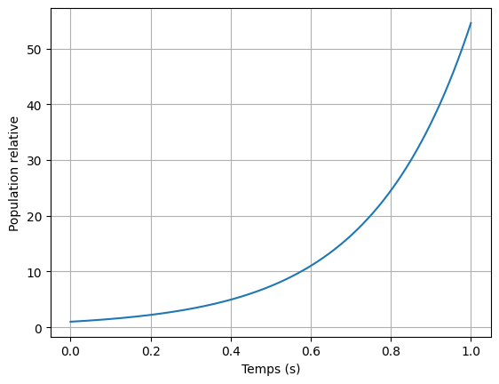

```
au bout de 1 seconde : 54.59
```

```python
import numpy as np
import matplotlib.pyplot as plt

k=1.0001
T_vie_s=25e-6

t=np.linspace(0, 1+1e-5, int(1e5))
# Population au bout de 1s
nb_generartions=t/T_vie_s
# Evolution de la population
P = k**nb_generartions

plt.plot(t, P)
plt.xlabel('Temps (s)')
plt.ylabel('Population relative')
plt.grid()
plt.show()

print('au bout de 1 seconde : {:.2f}'.format(P[-1]))
# On évolue de façon exponentielle, donc on atteint des valeurs énormes très rapidement.
```